# Logistic regression

## Objectives

- You can do or understand at least one of the following goals
1. You can perform logistic regression using R
2. You can interpret the result of logistic regression (you can understand \(\beta\) and \(exp(\beta)\))
3. You can understand \(R^2\) in linear regression
4. You can tell correlation coefficient from regression coefficient

## Youtube lecture on R

#### Logistic regression

[Lecture 11.1](https://youtu.be/A5IPy0NuzD4), [Lecture 11.2](https://youtu.be/aUZNCO4GDfQ), [Lecture 11.3](https://youtu.be/-tM-RoI6tyI), [Lecture 11.4](https://youtu.be/L47AlLm9G78), [Lecture 11.5](https://youtu.be/zRBQ7C2LdOE)

#### Online lecture

https://datascience-neurology.netlify.com/2019/08/23/online-r-lecture-youtube/

## Linear regression

## Motivation

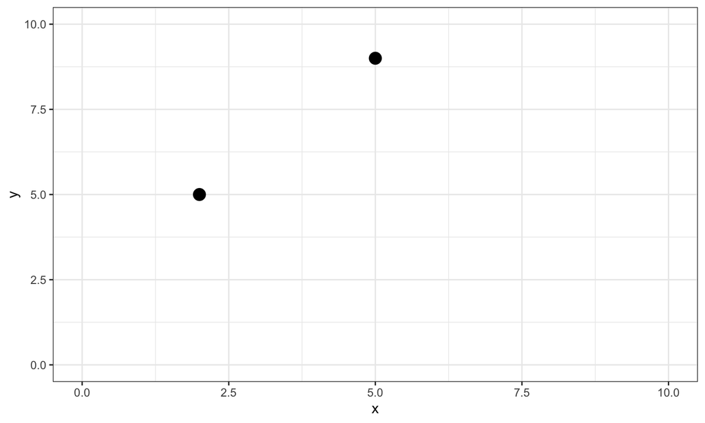

## Motivation

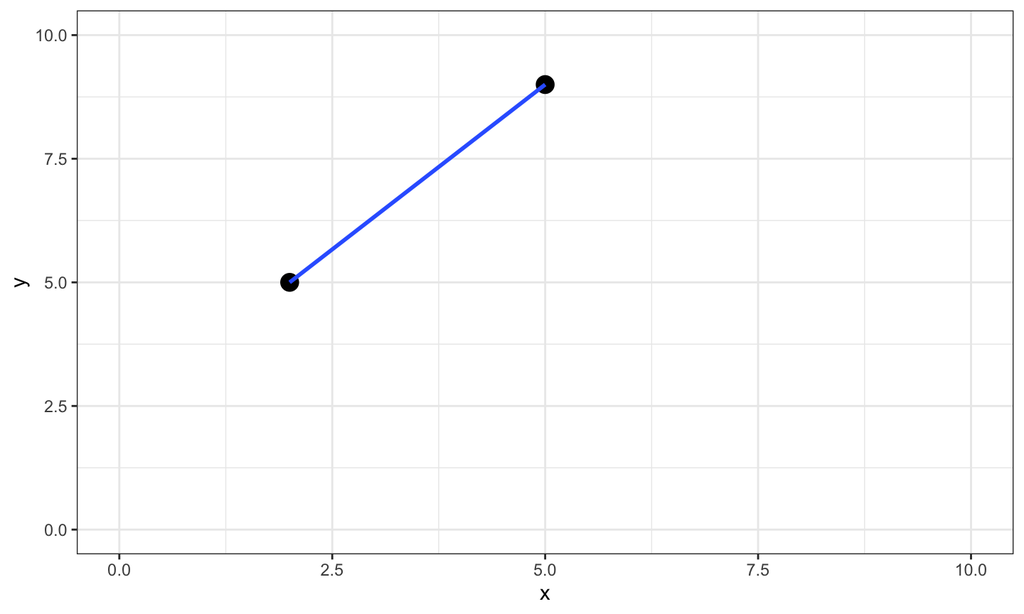

## Motivation

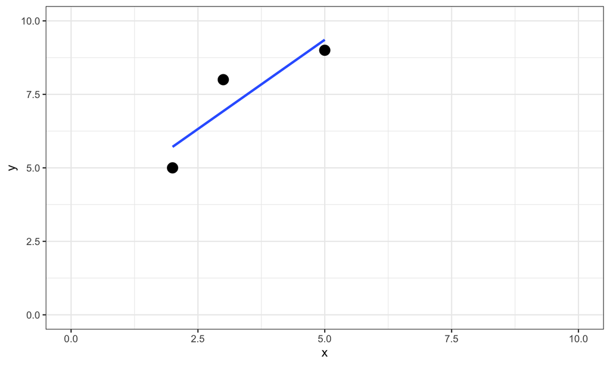

## Linear regression: Ordinary least square method

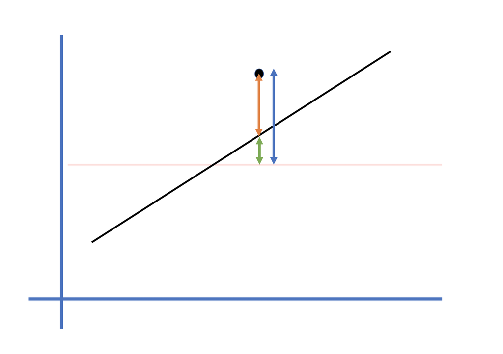

## Linear regression

- Dependent variable (continuous variable) can be explained by independent variables (continuous or categorical variables)

\[ y_i = \beta_0 + \beta_1 * x_1 + \epsilon_i\] \[\hat{\beta_0} = \overline{y} - \hat{\beta_1}*\overline{x}\] \[\hat{\beta_1} = \frac{\sum((x_i-\overline{x})*(y_i-\overline{y})}{\sum((x_i-\overline{x})^2)}\]

- Assumptions
  - \(\epsilon_i \sim N(0, \sigma^2)\)
  - Y: normal distribution
  - Y: equal variance around the mean

## Sample size (rule of thumb)

- Multiple linear regression
  - > 20 subjects per independent variable
- Multiple logistic regression
  - > 10 outcomes per independent variable
  - Number of outcome is either Y = 1 or Y = 0 which is smaller

## How to perform linear regression

1. Draw plot
2. Perform regression test
3. Check the model fit
4. Check the \(\beta\)s
5. Check multicollinearity

## 3. Model fit

- 결정계수: coefficient of determination: \(R^2\)
  - squared correlation coefficient between \(y_i\) and \(\hat{y}\)
  - how much variance of y can be explained by model.
- F test
  - \(H_0\): all \(\beta\)s are 0

## Linear regression: Ordinary least square method

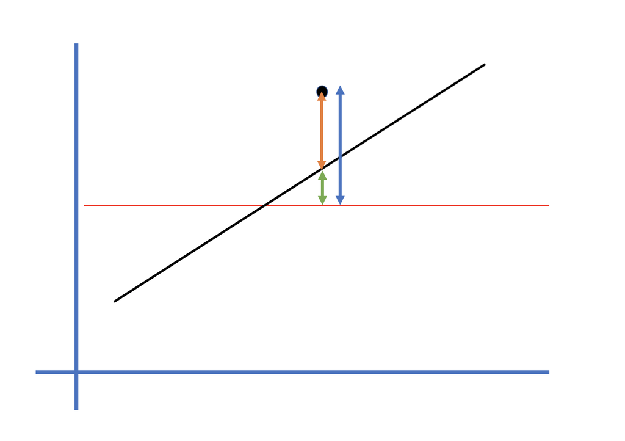

## Objectives

- You can do or understand at least one of the following goals
1. You can perform logistic regression using R
2. You can interpret the result of logistic regression (you can understand \(\beta\) and \(exp(\beta)\))

3. You can understand \(R^2\) in linear regression

4. You can tell correlation coefficient from regression coefficient

## Logistic regression

## Sigmoid function

\[S(t) = \frac{1}{1 + exp(-t)}\]

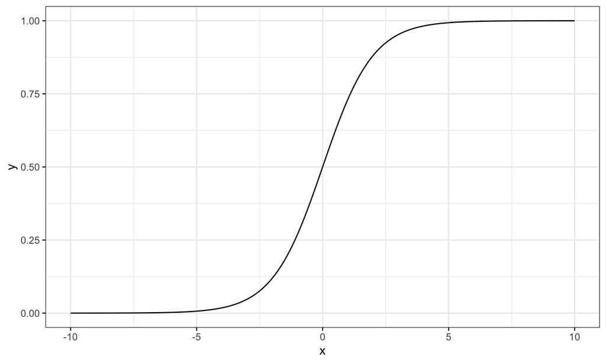

## Logistic function

\[q(x) = \frac{L}{1 + exp(-k(x - x0))}\] - logistic function: general form of sigmoid function

## Logistic function to logistic regression

\[f(x) = \frac{exp(\beta_0 + \beta_1*x_1)}{1 + exp(\beta_0 + \beta_1*x_1)}\]

[figure not shown]

## Logistic function to logistic regression

\[f(x) = \frac{exp(\beta_0 + \beta_1*x_1)}{1 + exp(\beta_0 + \beta_1*x_1)}\]

\[ln(Odds) = ln(\frac{f(x)}{1-f(x)}) = ln(\frac{P(Y=1)}{1-P(Y=1)}) = \beta_0 + \beta_1*x_1\]

- ln(odds) = logit

\[logit(p(x)) = ln(\frac{p}{1-p}) = \beta_0 + \beta_1*x_i + \epsilon_i\]

## OR (odds ratio)

\[ln(Odds) = ln(\frac{P(Y=1)}{1-P(Y=1)}) = \beta_0 + \beta_1*x_1\]

- if \(x_1 = 1\)

\[ln(Odds(x_1 = 1)) = \beta_0 + \beta_1\]

- if \(x_1 = 0\)

\[ln(Odds(x_1 = 1)) = \beta_0\]

\[ln(\frac{Odds(x_1 = 1)}{Odds(x_1 = 0)}) = ln(Odds(x_1 = 1)) - ln(Odds(x_1 = 0)) = \beta_1\]

\[OR = exp(\beta_1)\]

## Objectives

- You can do or understand at least one of the following goals
1. You can perform logistic regression using R
2. You can interpret the result of logistic regression (you can understand \(\beta\) and \(exp(\beta)\))

3. You can understand \(R^2\) in linear regression

4. You can tell correlation coefficient from regression coefficient

## Logistic regression

- Dependent variable (categorical variable) can be explained by independent variables (continuous or categorical variables)
- Maximum likelihood estimation (cf> Ordinary least square method in linear regression)
- Hosmer and Lemeshow Goodness of fit test
  - p > 0.05 means no evidence of poor fit.
- Nagelkerke \(R^2\) : SPSS
- Cox-Snell \(R^2\) : SAS and SPSS
  - https://statisticalhorizons.com/r2logistic

## Sample size (rule of thumb)

- Multiple linear regression
  - > 20 subjects per independent variable
- Multiple logistic regression
  - > 10 outcomes per independent variable
  - Number of outcome is either Y = 1 or Y = 0 which is smaller

## How to perform logistic regression

1. Check the variables and the number of event
2. Bivariate analyses
3. Perform regression test
4. Check the model fit
5. Check the \(\beta\)s
6. Check multicollinearity

## Import DB

```r
library(MASS)
data("birthwt")
```

## 1. Check the variable

```r
table(birthwt$low)
```

```
##
##   0   1
## 130  59
```

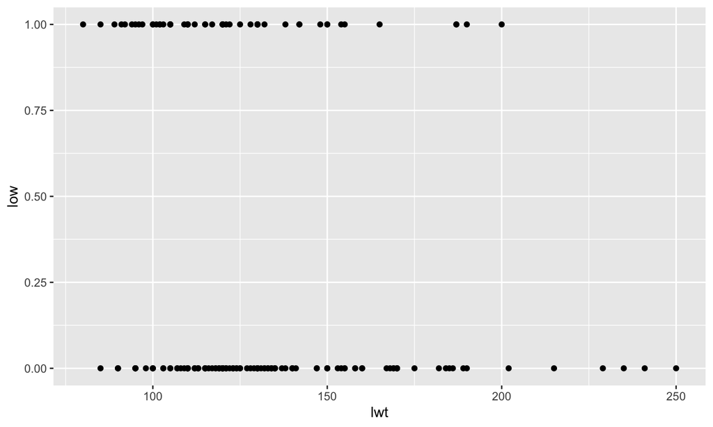

```r
ggplot(birthwt, aes(x = lwt, y = low)) + geom_point()
```

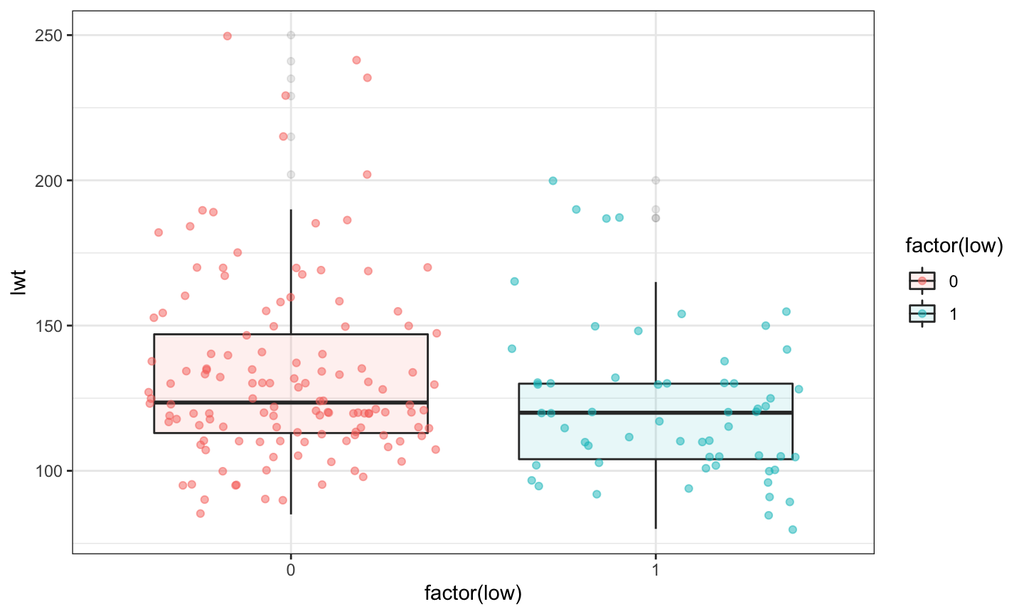

```r
ggplot(birthwt, aes(x = factor(low), y = lwt, fill = factor(low))) +
  geom_boxplot(alpha = 0.1) +
  geom_jitter(aes(color = factor(low)), alpha = 0.5) +
  theme_bw()
```

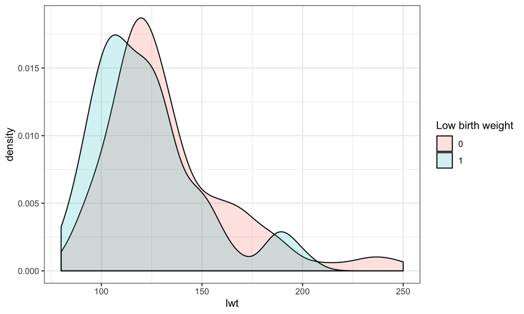

```r
ggplot(birthwt, aes(x =  lwt, fill = factor(low))) +
  geom_density(alpha = 0.2) + theme_bw() +
  scale_fill_discrete("Low birth weight")
```

## 2. Bivariate analysis

- Dependent variable: categorical
- if independent variable: categorical
  - \(\chi^2\) test
  - Fisher’s exact test
- if independent variabls: continuous
  - Student’s t test
  - Mann-Whitney or Wilcoxon rank sum test

## 3. Perform logistic regression

- birthwt shuuld not have missing values.

```r
result <- glm(low ~ lwt + age + ht + smoke, data = birthwt,
    family = binomial)
```

## 4. Model fit

- Hosmer & Lemeshow goodness of fit

```r
library(ResourceSelection)
```

```
## ResourceSelection 0.3-5   2019-07-22
```

```r
hoslem.test(result$y, fitted(result))
```

```
##
##  Hosmer and Lemeshow goodness of fit (GOF) test
##
## data:  result$y, fitted(result)
## X-squared = 4.0767, df = 8, p-value = 0.8501
```

- Nagelkerke \(R^2\)

```r
library(fmsb)
NagelkerkeR2(result)
```

```
## $N
## [1] 189
##
## $R2
## [1] 0.1344158
```

## 5. \(\beta\) or \(exp(\beta)\)

```r
summary(result)
```

```
##
## Call:
## glm(formula = low ~ lwt + age + ht + smoke, family = binomial,
##     data = birthwt)
##
## Deviance Residuals:
##    Min      1Q  Median      3Q     Max
## -1.692  -0.842  -0.657   1.188   2.219
##
## Coefficients:
##              Estimate Std. Error z value Pr(>|z|)
## (Intercept)  1.766856   1.052266   1.679  0.09313 .
## lwt         -0.016955   0.006623  -2.560  0.01047 *
## age         -0.035687   0.033365  -1.070  0.28480
## ht           1.788156   0.685882   2.607  0.00913 **
## smoke        0.679020   0.331939   2.046  0.04079 *
## ---
## Signif. codes:  0 '***' 0.001 '**' 0.01 '*' 0.05 '.' 0.1 ' ' 1
##
## (Dispersion parameter for binomial family taken to be 1)
##
##     Null deviance: 234.67  on 188  degrees of freedom
## Residual deviance: 215.68  on 184  degrees of freedom
## AIC: 225.68
##
## Number of Fisher Scoring iterations: 4
```

## formula

\[f(x) = \frac{exp(\beta_0 + \beta_1*x_1)}{1 + exp(\beta_0 + \beta_1*x_1)}\]

## Odds ratio

\[ln(Odds) = ln(\frac{P(Y=1)}{1-P(Y=1)}) = \beta_0 + \beta_1*x_1\]

\[ln(\frac{Odds(ht = 1)}{Odds(ht = 0)}) = ln(Odds(ht = 1)) - ln(Odds(ht = 1)) = 1.79\]

\[OR = exp(1.79) = 5.978418\]

## result of logistic regression

```r
coef(result)
```

```
## (Intercept)         lwt         age          ht       smoke
##  1.76685576 -0.01695511 -0.03568724  1.78815623  0.67902040
```

```r
exp(coef(result))
```

```
## (Intercept)         lwt         age          ht       smoke
##   5.8524230   0.9831878   0.9649420   5.9784194   1.9719451
```

```r
confint(result)
```

```
##                   2.5 %       97.5 %
## (Intercept) -0.24303022  3.899499577
## lwt         -0.03078896 -0.004668962
## age         -0.10299314  0.028367348
## ht           0.48215833  3.228623435
## smoke        0.02958821  1.334845690
```

```r
confint(result) %>% exp()
```

```
##                 2.5 %     97.5 %
## (Intercept) 0.7842478 49.3777332
## lwt         0.9696802  0.9953419
## age         0.9021332  1.0287735
## ht          1.6195662 25.2448818
## smoke       1.0300303  3.7994096
```

## Objectives

- You can do or understand at least one of the following goals
1. You can perform logistic regression using R

2. You can interpret the result of logistic regression (you can understand \(\beta\) and \(exp(\beta)\))

3. You can understand \(R^2\) in linear regression

4. You can tell correlation coefficient from regression coefficient

## 6. Multicollinearity

```r
library(car)
vif(result)
```

```
##      lwt      age       ht    smoke
## 1.158363 1.019751 1.137391 1.000308
```

- vif > 2.5 problematic
- vif > 10 serious

```r
library(performance)
check_collinearity(result)
```

```
## # Check for Multicollinearity
##
## Low Correlation
##
##  Parameter  VIF Increased SE
##        lwt 1.16         1.08
##        age 1.02         1.01
##         ht 1.14         1.07
##      smoke 1.00         1.00
```

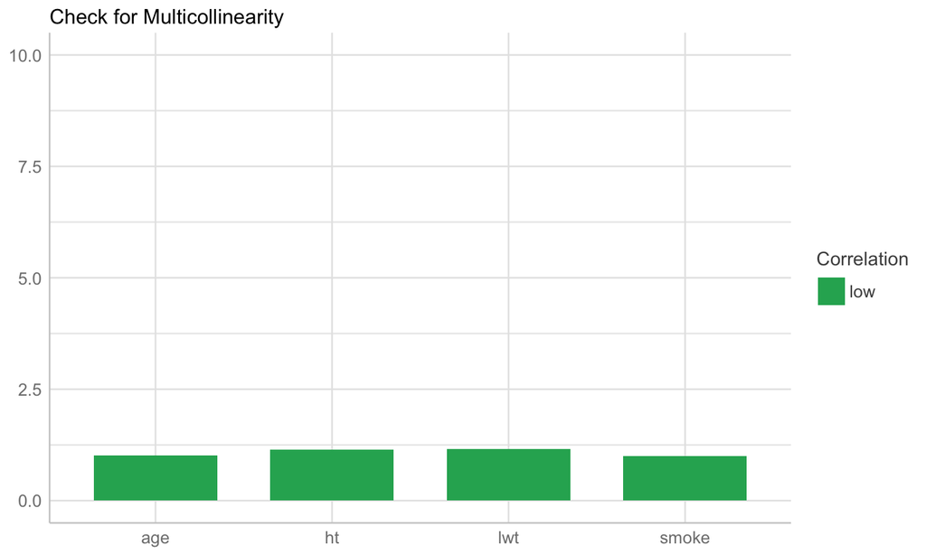

```r
x <- check_collinearity(result)
plot(x)
```

## Objectives

- You can do or understand at least one of the following goals

1. You can perform logistic regression using R

2. You can interpret the result of logistic regression (you can understand \(\beta\) and \(exp(\beta)\))

3. You can understand \(R^2\) in linear regression

4. You can tell correlation coefficient from regression coefficient